# Análise de Cluster

Jonatha Azevedo

[figure not shown]

Nesse relatório, encontra-se duas abordagens para algoritmos de agrupamentos, um hierárquico e um não hierárquico. Com a proposta de usar um banco de dados e simular uma clusterização, iremos definir os clusters com base na metodologia definida em sala de aula. E usaremos alguma métrica pra definir se o agrupamento foi feito de uma forma razoável.

### Análise Exploratória dos dados

```r
#Carreganod os dados
dados <- read.csv2("Dados_Vendas.csv", header=T, stringsAsFactors = F)
head(dados)
```

```
##   Funcionário Vendas Lucro Clientes Escrita Lógica Social Matemática
## 1           1  23.25 24.00    24.45     4.5    6.0    4.5       10.0
## 2           2  22.20 22.95    24.20     3.5    5.0    5.0        7.5
## 3           3  23.75 25.07    24.75     4.0    6.0    4.5       13.0
## 4           4  25.32 25.95    26.70     6.5    7.0    6.0       14.5
## 5           5  25.50 26.95    25.75     5.0    7.5    6.0       16.0
## 6           6  23.95 24.37    24.82     5.0    7.0    5.5       10.5
```

Antes de entrar na modelagem de clusters, precisamos conhecer os dados. Temos, para esse trabalho, dados de vendas de vendedores de uma certa loja.

```r
summary(dados)
```

```
##   Funcionário        Vendas          Lucro          Clientes
##  Min.   : 1.00   Min.   :20.37   Min.   :22.45   Min.   :23.57
##  1st Qu.:11.75   1st Qu.:23.51   1st Qu.:24.75   1st Qu.:24.75
##  Median :22.50   Median :25.16   Median :26.56   Median :25.79
##  Mean   :22.50   Mean   :24.75   Mean   :26.69   Mean   :25.68
##  3rd Qu.:33.25   3rd Qu.:26.50   3rd Qu.:29.03   3rd Qu.:26.58
##  Max.   :44.00   Max.   :27.70   Max.   :30.57   Max.   :28.82
##     Escrita          Lógica         Social        Matemática
##  Min.   :2.500   Min.   : 4.0   Min.   :2.500   Min.   : 4.50
##  1st Qu.:4.375   1st Qu.: 6.0   1st Qu.:4.500   1st Qu.:10.38
##  Median :5.000   Median : 7.0   Median :5.500   Median :15.75
##  Mean   :5.648   Mean   : 7.0   Mean   :5.273   Mean   :15.00
##  3rd Qu.:7.000   3rd Qu.: 8.5   3rd Qu.:6.000   3rd Qu.:19.50
##  Max.   :9.000   Max.   :10.0   Max.   :7.500   Max.   :25.50
```

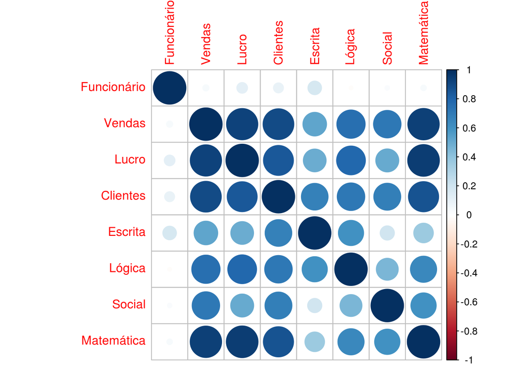

```r
require(corrplot)
names(dados) <- names(dados)
corrplot(cor(dados))
```

Podemos ver que temos bastantes correlação entre as variáveis. Fato que pode auxiliar na clusterização. Embora, nesse trabalho o processo seja geral e não levando em conta alguma variável para definir melhor os centróides de cada cluster.

## Análise de cluster

Conhecido como “agrupamento”, é um conjunto de técnicas que permeite os agrupar elementos de um banco de dados de acordo com suas características, facilitando reconhecer relações e padrões existentes entre os indivíduos de cada grupo ***(*cluster*)**.

Sempre queremos formar cluster que possuem grande homogeniedade dentro de si e grande enterogeneidade entre os cluster, entre os grupos. Então, intuitivamente, queremos obter medidas de similaridades para organizar e distribuir os elementos no banco de dados aos clusters.

Por definições encontradas em artigos, temos as duas abordagens citadas a cima:

- **Hierárquica**: se divide nas abordagens aglomerativas ou divisivas;
- **Não hierárquica**: baseada no famoso algoritmo de K-means.

A algumas medidas de similaridades, mas largamente mais usada é a de distância. Por representar melhor o conceito de proximidade, entre outras razões. A principal ferramenta nesse caso, é a **matriz de Similaridade (SM)**.

### Método hierárquico

```r
k = 6
```

Não necessáriamente, precisamos sempre definir o número de clusters para a modelagem. O ideal seria obter esse número de uma forma variante e específica para cada contexto.

Usando o método euclidiano (o **`R`** com a função **`dist()`**, possui 6 métodos: euclidiano, por máximo, manhattam, camberra, binário e minkowski) para calcular a distância, ou seja: $d(X_{i},X_{j}) = \sqrt{\sum\limits^{p}_{h=1}(X_{hi} - X_{hj})}$, logo a matriz de similaridade, conterá todos os valores $d(X_{i},X_{j})$ o que facilita a identificação dos pares mais similares.

```r
dist <- dist(dados,method = "euclidean" ,diag=T, upper=T)
```

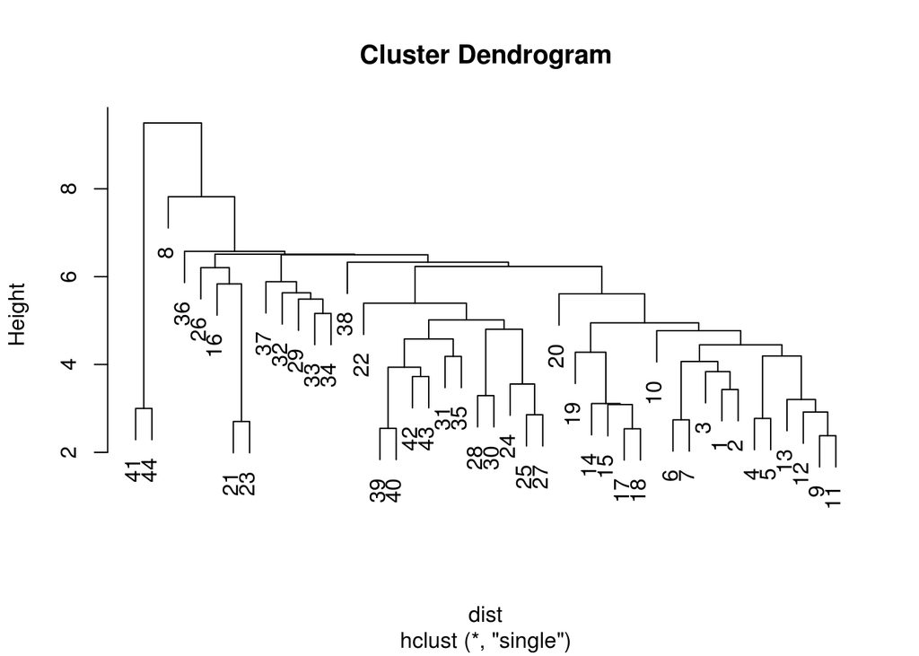

```r
clusters <- hclust(dist, "single")
plot(clusters)
```

O dendograma anteior não está muito claro para definirmos um número adequado ou razoavel de clusters. Logo, vamos utilizar alguns parâmetros na função **`hclust`**.

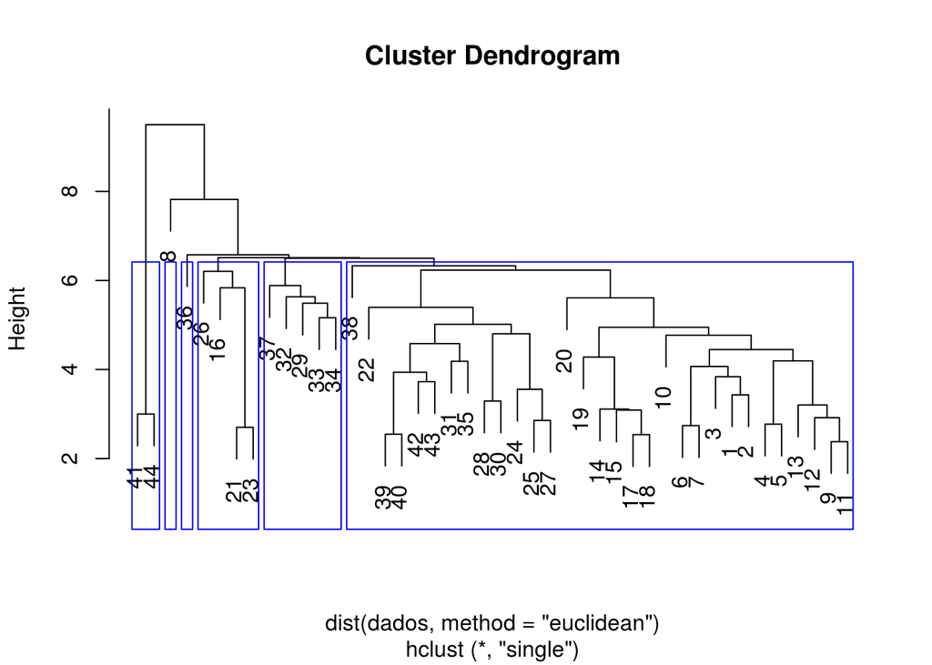

```r
dend1.1=hclust(dist(dados, method = "euclidean"),"single") # method - o metodo utilizado (completa, simples, ward...)
plot(dend1.1)
rect.hclust(dend1.1, k = 6, border = "blue")
```

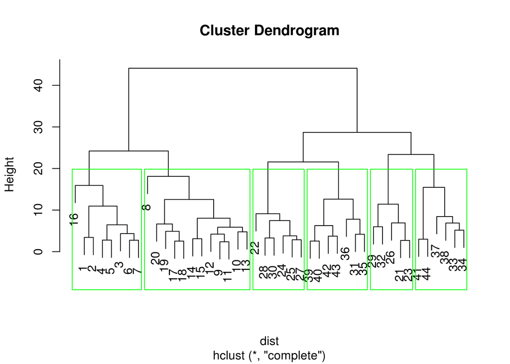

```r
dend1.2=hclust(dist,"complete") # method - o metodo utilizado (completa, simples, ward...)
plot(dend1.2)
rect.hclust(dend1.2, k = 6, border = "green")
```

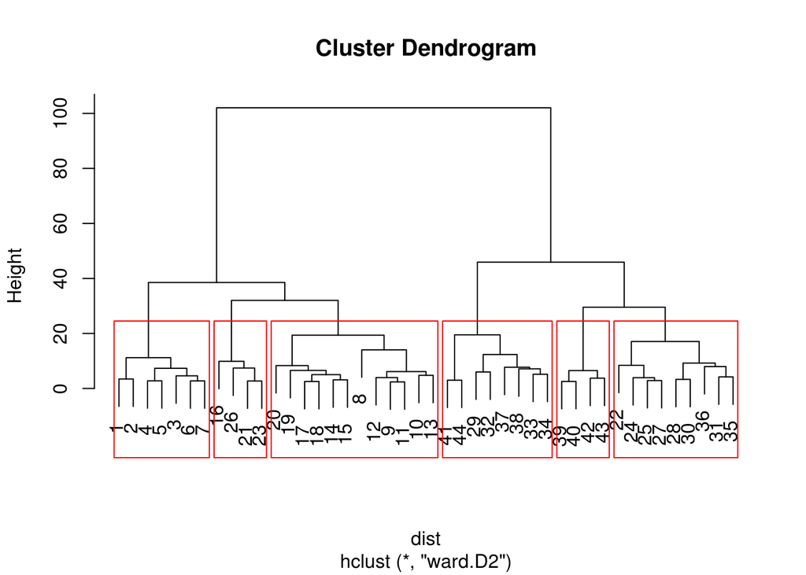

```r
dend1.3=hclust(dist,"ward.D2") # method - o metodo utilizado (completa, simples, ward...)
plot(dend1.3)
rect.hclust(dend1.3, k = 6, border = "red")
```

Precisamos de uma métrica para definir se a clusterização foi razoavel. Talvez olhar para a distribuição de elementos dentro de cada clusters seja uma medida a se considerar. Ou seja, quanto mais equilibrado o número de lementos em cada cluster, quer dizer que a clusterização foi adequada.

Primeiro adiciono o indice que refenrica o elemento a seu cluster.

```r
dados_clusters <- cbind(dados,grupo=cutree(dend1.3,h=6))
head(dados_clusters)
```

```
##   Funcionário Vendas Lucro Clientes Escrita Lógica Social Matemática grupo
## 1           1  23.25 24.00    24.45     4.5    6.0    4.5       10.0     1
## 2           2  22.20 22.95    24.20     3.5    5.0    5.0        7.5     1
## 3           3  23.75 25.07    24.75     4.0    6.0    4.5       13.0     2
## 4           4  25.32 25.95    26.70     6.5    7.0    6.0       14.5     3
## 5           5  25.50 26.95    25.75     5.0    7.5    6.0       16.0     3
## 6           6  23.95 24.37    24.82     5.0    7.0    5.5       10.5     2
```

Abaixo, a ideia é chegar ao mesmo resultado, só que considerando um método não hierárquico. Utilizando o algoritmo de **K-means**.

### Método não hierárquico

Utilizando o algoritmo já implementado no R, faremos os clusters definindo inicialmente os números da quantidade de centros.

O algorítmo de k-means é uma iteração, basicamente, ele consiste em fazer uma escolha inicial dos k elementos que formam as sementes iniciais. Esta escolha pode ser feita da seguinte forma:

- Selecionado as k primeiras observações
- Selecionando k observações aleatorioamente; e
- Escolhendo k observações de modo que seus valores sejam bastente diferentes.

Escolhida as sementes iniciais, é calculada a distância de cada elemento em relação às sementes., agrupando o elemento ao grupo que possuir a menor distância e recalculando o centróide do mesmo. O procedimento, naturalmente, é repetido até que todos os elementos facam parte de um dos clusters.

Com isso permitimos que os centróides iniciados aleatoriamente se ajustem e melhorem a similaridade intragrupo. Isto é feito minimizando o erro do agrupamento, que é definida como a soma das distâncias euclidianas entre cada indivíduo e o centróide de seu respectivo grupo, isto é,

$$E = \sum\limits_{K}^{k=1}\sum\limits_{X_{i}\in C_{k}}^{}d(X_{i},y_{k})$$

onde $K$ é o total de grupos definidos, $d(X_{i}, y_{k})$ é a distância entre os indivíduos $X_{i}$ e o centróide $y_{k}$ do cluster $C_{k}$. O método de cálculo da distância também é o euclidiano definido anteriormente.

Faremos para 3 casos:

```r
kmeans_out1 <- kmeans(dados,centers = 4)
kmeans_out2 <- kmeans(dados,centers = 5)
kmeans_out3 <- kmeans(dados,centers = 6)
sizes <- list(size_4clusters = kmeans_out1$size,size_5clusters = kmeans_out2$size,size_6clusters = kmeans_out3$size);sizes
```

```
## $size_4clusters
## [1] 11 12 13  8
##
## $size_5clusters
## [1]  7 10  7 10 10
##
## $size_6clusters
## [1]  8 10  7  7  6  6
```

```r
dados_clusters_kmeans = cbind(dados,grupo = kmeans_out3$cluster)
head(dados_clusters_kmeans)
```

```
##   Funcionário Vendas Lucro Clientes Escrita Lógica Social Matemática grupo
## 1           1  23.25 24.00    24.45     4.5    6.0    4.5       10.0     3
## 2           2  22.20 22.95    24.20     3.5    5.0    5.0        7.5     3
## 3           3  23.75 25.07    24.75     4.0    6.0    4.5       13.0     3
## 4           4  25.32 25.95    26.70     6.5    7.0    6.0       14.5     3
## 5           5  25.50 26.95    25.75     5.0    7.5    6.0       16.0     3
## 6           6  23.95 24.37    24.82     5.0    7.0    5.5       10.5     3
```

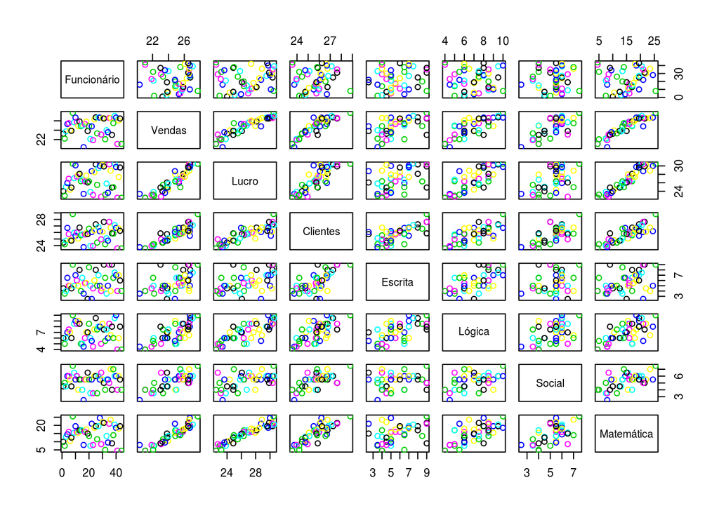

```r
plot(dados, col = c(1,3,5,4,6,7))
points(kmeans_out3$centers, col = 1:4, pch = 8)
```

```r
sort(kmeans_out3$cluster)
```

```
##  [1] 1 1 1 1 1 1 1 1 2 2 2 2 2 2 2 2 2 2 3 3 3 3 3 3 3 4 4 4 4 4 4 4 5 5 5
## [36] 5 5 5 6 6 6 6 6 6
```

Como são poucos dados, optar por um número de clusters muito alto não parece nos dar muito ganho. Usamos uma métrica para medir o quão razoável foi a clusterização verificando o balanceamento da distribuição de elementos em cada grupo. Então por isso, vamos escolher 6 centros, como anteiormente.